# Tutorial on pre-processing

Kemeng Liu

28/02/2023

## Introduction

This tutorial presents the data pre-processing part of a statistical analysis that aims at estimating the impact of KfW financing on reducing deforastation rates in terrestrial *protected areas (PA)*.

In the statistical analysis, the deforastation rates in funded protected areas *(treatment group)* will be compared with that in non-protected regions *(control group)* in both pre- and post-project phase in a user-specified country. When selecting samples for treated group and control group, a so-called **“matching”** strategy is followed in order to mitigate selection bias.

The “matching” will be taken over by R package `Matchit` (more details in next tutorial), which requires a **matching dataframe** as input. The goal of this tutorial is to guide users through a pre-designed data processing flow to generate a matching frame for a given country.

So what is a *matching frame*? In fact, it is a dataframe containing **observations** from all treated areas and non-treated areas in one country. Each row represents an observation and each column contains **attributes** for individual observations.

And what do we consider an *observation*? In our method design, a squared grid at user-specified ground spacing is distributed over the studied country, and each grid cell corresponds to an obervation.

This tutorial is structured as follows:

- Section 1: Initial settings;
- Section 2: Generating observation units for matching frame;
- Section 3: Determining **Group IDs** and **WDPA IDs** for all observation units;
- Section 4: Calculating **deforestation area** and other **covariates** for all observation units, by means of a KfW initiated R package `mapme.biodiversity`.

## 1. Initial Settings

Let’s firstly load the needed R packages. Since `mapme.biodiversity` package is still undergoing development, it is recommended to install the package directly from Github to get its most recent version by calling `remotes::install_github("mapme-initiative/mapme.biodiversity", upgrade="always")`.

```r
# Load Libraries
library(dplyr)
library(tidyr)
library(stringr)
library(ggplot2) # For plotting
library(sf) # For handling vector data
library(terra) # For handling raster data
library(raster) # For handling raster data
library(rgeos)
library(geodata) # For getting country files
library(wdpar) # For getting protected areas
library(exactextractr) # For zonal statistics
#remotes::install_github("mapme-initiative/mapme.biodiversity", upgrade="always")
library(mapme.biodiversity)
library(aws.s3)
#Install the river to download wdpa data directly
webdriver::install_phantomjs()
```

Let’s then define some user-specified variables. **This tutorial is composed in the way that, once our readers specify the variables listed below, the final matching frame can be generated with rest of the codes staying untouched, as long as the covariates are the same.** In case different covariates are wanted, users should modify the codes as guided in section 4.

The variables to be specified by users are:

- **`wdir`**: Path to a working directory; all output and intermediate files will be written to this directory.
- **`name_output`**: Name of the output matching frame. The suffix represents file format of geospatial dataframe; the usual options are `.gpkg`, `.shp` or `.geojson`.
- **`country`**: The name of the studied country. Both full country name and 3-digit ISO country code are valid. *A list of country names and equivalent ISO codes are available [here](https://en.wikipedia.org/wiki/ISO_3166-1#Officially_assigned_code_elements)*.
- **`buffer_m`**: The width of buffer zones around PAs in meter.
- **`gridSize`**: The length of a grid cell in meter.
- **`wdpaid`**: The official IDs of funded PAs.
- **`y_first`**/**`y_last`**: The first and the last year that the analysis should cover.

```r
# Define the path to a working directory
# wdir = file.path("C:/EAGLE/kfw_internship/git_myBranch/MDG/mapme.pa-impact-evaluation/data")
wdir = paste(tempdir(), "mapme", sep = "/")

# Define the file name of the output matching frame
name_output = "matching_frame_10km.gpkg"

# Specify a country;
country = "CMR"

# Specify buffer width in meter
buffer_m = 10000
# Specify the grid cell size in meter
gridSize = 10000

data_stat_nodupl =
  #fread("data_tidy/BDD_DesStat_nofund_nodupl.csv" , encoding = "UTF-8")
  aws.s3::s3read_using(
  FUN = data.table::fread,
  encoding = "UTF-8",
  # Mettre les options de FUN ici
  object = "data_tidy/BDD_DesStat_nofund_nodupl.csv",
  bucket = "projet-afd-eva-ap",
  opts = list("region" = ""))
# Specify a list of WDPA IDs of funded protected areas (treated areas)
paid = data_stat_nodupl[data_stat_nodupl$iso3 == country,]$wdpaid

# Start year
y_first = 2000
# End year
y_last = 2021
```

## 2. Generating observation units for matching frame

As indicated in the introduction, observations in a matching frame correspond to individual grid cells of a vector grid in our method design. In this section, we are going to create a squared grid at 10 km ground resolution (defined by `gridSize`).

```r
# Download country polygon to working directory and load it into workspace
gadm <- gadm(country = country, resolution = 1, level = 0, path = wdir) %>%
  st_as_sf()
# If the country polygon file already exists in working directory, it can be loaded into work space by
#gadm = readRDS(file.path(wdir, <"name_of_the_file">)) %>% st_as_sf()
```

The code chunk below projects the country polygon into a projected *Geographical Coordinate System (CRS)*, i.e. the planar WGS84 UTM zone where the polygon’s centroid stands. It is beyond the scope of this tutorial to roll out explanations on CRS because it is a broad technical domain in remote sensing and geoinformatics. For readers who are interested in learning more about it, this [book chapter](https://r.geocompx.org/reproj-geo-data.html#which-crs) gives a nice start. Otherwise you don’t have to bother with this issue because the projection is done automatically for the specified country.

The solution given here to cope with CRS is to some extent traded-off for the convenience of computation, but we consider the bias risen here is tolerable for our use case, because the later statistical analysis has a stronger focus on depicting changes and extracting trends.

```r
# Find UTM zone of the country centroid
centroid = st_coordinates(st_centroid(gadm))
lonlat2UTM = function(lonlat) {
  utm = (floor((lonlat[1] + 180) / 6) %% 60) + 1
  if (lonlat[2] > 0) {
    utm + 32600
  } else{
    utm + 32700
  }
}
utm_code = lonlat2UTM(centroid)
# Reproject GADM
gadm_prj = gadm %>% st_transform(crs = utm_code)
```

```r
# Make bounding box of projected country polygon
bbox = st_bbox(gadm_prj) %>% st_as_sfc() %>% st_as_sf()

# Make a Grid to the extent of the bounding box
grid.ini = st_make_grid(bbox, cellsize = c(gridSize,gridSize))

# Crop Grid to the extent of country boundary by
  # subsetting to the grid cells that intersect with the country
grid.sub = grid.ini %>%
  st_intersects(gadm_prj, .) %>%
  unlist()
  # Filter the grid to the subset
grid = grid.ini[sort(grid.sub)] %>%
  st_as_sf() %>%
  mutate(gridID = seq(1:nrow(.))) # Add id for grid cells
```

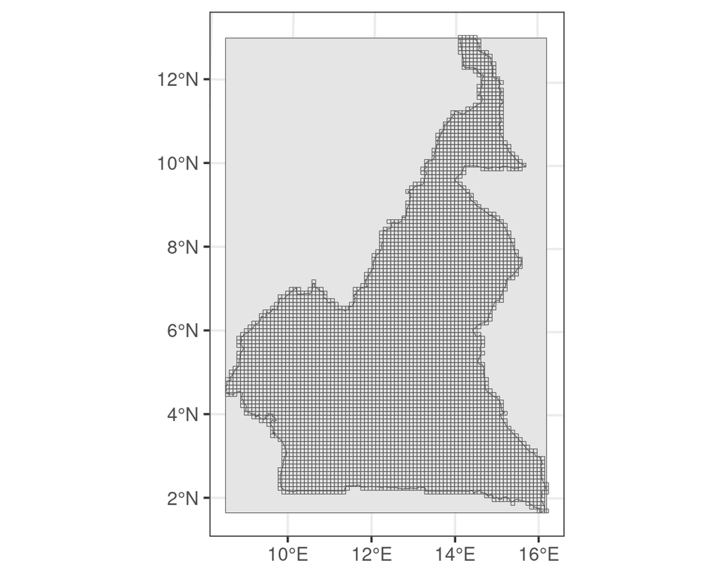

```r
# Visualize
ggplot() +
  geom_sf(data = st_geometry(bbox)) +
  geom_sf(data = st_geometry(gadm_prj)) +
  geom_sf(data = st_geometry(grid), alpha = 0)
```

## 3. Determining Group IDs and WDPA IDs for all observation units

Now that we have the vector grid ready, in this section we’re going to assign `Group ID` and `WDPA ID` as attributes to each observation unit (i.e. grid cell). This is achieved by:

**A**. Getting the vector file of all protected areas in a specified country;

**B**. Making buffer zones in specified width around all protected areas;

**C**. Assigning number `3` as `Group ID` to all buffer polygons;

**D**. Separating the protected areas funded by KfW from the others;

**E**. Assigning number `1` as `Group ID` to funded PA polygons and number `2` to not funded ones;

**F**. Rasterizing PA and buffer polygons by assigning their `Group ID` values to raster pixels;

**G**. Rasterizing PA polygons by assigning the `WDPA ID` to raster pixels;

**H**. Laying the previously generated grid over both rasters, agrregating values from pixels that are covered by individual grid cell, and sorting each grid cell into groups and WDPA IDs based on the aggregated value.

- **Step-A**

```r
# Get the PA polygons/points of the specified country;
# They're downloaded to the working directory.
wdpa = wdpa_fetch(country, wait = TRUE, download_dir = wdir)

# If the PA file already exists, it can be loaded in this way
#wdpa = wdpa_read(paste0(wdir, '/WDPA_Dec2022_MDG-shapefile.zip'))
```

```r
# PAs are projected, and column "geometry_type" is added
wdpa_prj = wdpa_clean(wdpa, geometry_precision = 1000) %>%
  # Remove the PAs that are only proposed, or have geometry type "point"
  filter(STATUS != "Proposed") %>%
  filter(GEOMETRY_TYPE != "POINT") %>%
  # Project PA polygons to the previously determined UTM zone
  st_transform(crs = utm_code)
```

- **Step-B & -C**

```r
# Make Buffers of 10km around all protected areas
buffer <- st_buffer(wdpa_prj, dist = buffer_m) %>%
  # Assign an ID "3" to the buffer group
  mutate(group=3)
```

- **Step-D & -E**

```r
# Separate funded and non-funded protected areas
wdpaID_funded = paid
wdpa_funded = wdpa_prj %>% filter(WDPAID %in% wdpaID_funded) %>%
  mutate(group=1) # Assign an ID "1" to the funded PA group
wdpa_nofund = wdpa_prj %>% filter(!WDPAID %in% wdpaID_funded) %>%
  mutate(group=2) # Assign an ID "2" to the non-funded PA group
```

```r
# Merge the dataframes of funded PAs, non-funded PAs and buffers
wdpa_groups = rbind(wdpa_funded, wdpa_nofund, buffer)
# Subset to polygons that intersect with country boundary
wdpa.sub = wdpa_groups %>%
  st_intersects(gadm_prj, .) %>%
  unlist()
# Filter the PA+buffer to the subset
wdpa_groups = wdpa_groups[sort(wdpa.sub),] %>%
  st_as_sf()
```

- **Step-F & -G**

```r
# Initialize an empty raster to the spatial extent of the country
r.ini = raster()
extent(r.ini) = extent(gadm_prj)
# Specify the raster resolution as same as the pre-defined 'gridSize'
res(r.ini) = gridSize
```

```r
# Assign the raster pixels with "Group" values,
# Take the minial value if a pixel is covered by overlapped polygons, so that PA Group ID has higher priority than Buffer ID.
# Assign value "0" to the background pixels (control candidates group)
r.group = rasterize(wdpa_groups, r.ini, field="group", fun="min", background=0) %>%
  mask(., gadm_prj)
# Rename Layer
names(r.group) = "group"

# Rasterize wdpaid
r.wdpaid = rasterize(wdpa_prj, r.ini, field="WDPAID", fun="first", background=0) %>%
  mask(., gadm_prj)
names(r.wdpaid) = "wdpaid"
```

- **Step-H**

```r
# Aggregate pixel values by taking the majority

grid.group = exact_extract(x=r.group, y=grid, fun='mode', append_cols="gridID") %>%
  rename(group = mode)

grid.wdpaid = exact_extract(x=r.wdpaid, y=grid, fun="mode", append_cols="gridID") %>%
  rename(wdpaid = mode)
```

```r
# Merge data frames
grid.param = grid.group %>%
  merge(., grid.wdpaid, by="gridID") %>%
  merge(., grid, by="gridID") %>%

  # drop rows having "NA" in column "group"
  drop_na(group) %>%
  # drop the column of "gridID"
  subset(., select=-c(gridID)) %>%
  st_as_sf() %>%
  # Grid is projected to WGS84 because mapme.biodiverty package merely works with this CRS
  st_transform(crs=4326)

head(grid.param)
```

```
## Simple feature collection with 6 features and 2 fields
## Geometry type: POLYGON
## Dimension:     XY
## Bounding box:  xmin: 15.78582 ymin: 1.65222 xmax: 16.14542 ymax: 1.923786
## Geodetic CRS:  WGS 84
##   group wdpaid                              x
## 1     3      0 POLYGON ((16.05543 1.65227,...
## 2     3      0 POLYGON ((15.87568 1.742819...
## 3     3      0 POLYGON ((15.96558 1.742775...
## 4     3      0 POLYGON ((16.05548 1.742727...
## 5     3      0 POLYGON ((15.78582 1.833323...
## 6     0      0 POLYGON ((15.87573 1.833281...
```

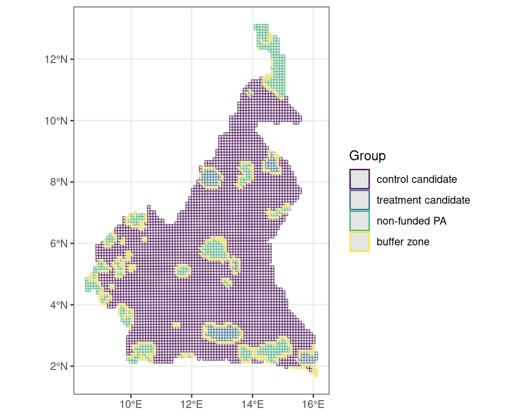

```r
# Visualize grouped grid cells
ggplot(grid.param) +
  geom_sf(aes(color=as.factor(group))) +
  scale_color_viridis_d(
    # legend title
    name="Group",
    # legend label
    labels=c("control candidate", "treatment candidate", "non-funded PA", "buffer zone")) +
  theme_bw()
```

## 4. Calculating deforestation area and other covariates for all observation units

Apart from Group and WDPA, we still need to fill our matching frame with other attributes. In this section we are going to calculate deforestation area in time series and other covariates as further attributes for all observations units (i.e. grid cells). This processing is implemented using KfW initiated open-source R package `mapme.biodiversity`.

As indicated in the introduction, covariates are the information that `Matchit` package will rely on to decide which observation units to consider as treated or control items in later statistical analysis.

The covariates selected for this demo are:

The indicator calculation with `mapme.biodiversity` package generally follows the following workflow:

1. Get input data ready for the calculation (function `init_portfolio()`);
2. Download raster data for the specified covariates and tree cover (function `get_resources()`);
3. Calculate the specified covariates and time series of tree cover (function `calc_indicators()`);

### 4.1. Initialize Portfolio

The function `init_portfolio()` will assign individual input polygon with an asset id, define a time span for tree area time series, specify the path to a directory for outputs and intermediate files, as well as core numbers for parallel processing if available.

Please note that the input study area (in our case the vector grid) must have a geometry type of **POLYGON** to be accepted by this function.

Furthermore, please be cautious**(!)** with the function argument `add_resources`. It is set to `TRUE` by default, which will stage the raster data directly for indicator calculation after being downloaded. Experience-wise this setting would trigger errors when the spatial extent of study area is extended or the directory path to the raster data changes. Therefore, it is strongly recommended to set **`add_resources = FALSE`**, in which case if the input study area changes, additional raster data will be downloaded and already existing data won’t be re-downloaded (no duplicated downloading).

```r
# Get input data ready for indicator calculation
aoi = init_portfolio(grid.param,
                     years = y_first:y_last,
                     outdir = wdir,
                     cores = 12,
                     add_resources = FALSE)
```

### 4.2. Download Rasters and Calculate Covariates

The demo script for calculating the pre-selected indicators can be run as it is, without requiring our tutorial followers to modify it. **But in case our readers wish to calculate new covariates, here is a short guide on how to do that, which is very simple!**

A list of all indicators supported by `mapme.biodiversity` package can be seen [here](https://mapme-initiative.github.io/mapme.biodiversity/). Once an indicator is selected,

- By typing `?<indicator_name>` in R console, e.g. `?soilproperties`, we can check **required resources** for download; e.g. for indicator `soilproperties`, the required resource is `soilgrids`.
- On the same documentation page as above, we can look for **indicator-specific arguments** needed for `calc_indicator()` function.
- By clicking at the resource name, or typing `?<resource_name>` in the R console, e.g. `?soilgrids`, we can look for **resource-specific arguments** needed for `get_resources()` function.

The calculation of the pre-selected covariates and forest cover time series in the code chunks below is shown as examples.

- **Covariate: Average Soil Clay Content at 0-5 cm depth**

```r
# Covariate: Soil
# Download Data
get.soil = get_resources(aoi,
              resources = c("soilgrids"),
              layers = c("clay"), # resource specific argument
              depths = c("0-5cm"), # resource specific argument
              stats = c("mean")) %>%
# Calculate Indicator
  calc_indicators(.,
                 indicators = "soilproperties",
                 stats_soil = c("mean"),
                 engine = "zonal") %>%
# Transform the output dataframe into a pivot dataframe
  unnest(soilproperties) %>%
  mutate(across(mean, round, 3)) %>% # Round numeric columns
  pivot_wider(names_from = c("layer", "depth", "stat"), values_from = "mean")
```

- **Covariate: Average Elevation**

```r
#Issues with the SSL certificate : at first, this resource is not downloaded

# Covariate: Elevation
# Download Raster Data
# get.elevation = get_resources(aoi, "nasa_srtm") %>%
# # Calculate Indicator
#   calc_indicators(.,
#                   indicators = "elevation",
#                   stats_elevation = c("mean")) %>%
# # Transform the output dataframe into a pivot dataframe
#   unnest(elevation)
```

- **Covariate: Terrain Ruggedness Index (TRI)**

```r
#Issues with the SSL certificate : at first, this resource is not downloaded

# Covariate: TRI
# Download Data
# get.tri = get_resources(aoi, "nasa_srtm") %>%
# # Calculate Indicator
#   calc_indicators(., indicators = "tri") %>%
# # Transform the output dataframe into a pivot dataframe
#   unnest(tri)
```

- **Covariate: Median Traveltime to cities with at least 5000 population**

```r
# Covariate: Travel Time
# Download Data
get.travelT = get_resources(aoi, resources = "nelson_et_al",
              range_traveltime = c("5k_110mio")) %>% # resource specific argument
# Calculate Indicator
  calc_indicators(.,
                 indicators = "traveltime",
                 stats_accessibility = c("median")) %>%
# Transform the output dataframe into a pivot dataframe
  unnest(traveltime) %>%
  pivot_wider(names_from = "distance", values_from = "minutes_median", names_prefix = "minutes_median_")
```

### 4.3. Calculate Deforestation Area in Time Series

We calculate time series of forest cover area in exactly the same way as for the other covariates.

```r
# Time Series of Tree Cover Area
# Download Data
get.tree = get_resources(aoi, resources = c("gfw_treecover", "gfw_lossyear")) %>%
# Calculate time series
  calc_indicators(.,
                 indicators = "treecover_area",
                 min_size=1, # indicator-specific argument
                 min_cover=10) %>% # indicator-specific argument
# Transform the output dataframe into a pivot dataframe
  unnest(treecover_area) %>%
  mutate(across(treecover, round, 3)) %>% # Round numeric columns
  pivot_wider(names_from = "years", values_from = "treecover", names_prefix = "treecover_")
```

Unlike for forest cover time series and other covariates, the calculation of deforestation area is more straitforward because it is directly conducted on dataframe base. **The deforested area in year** $Y_{n}$ is derived from subtracting the forest area in year $Y_{n}$ by the forest area in year $Y_{n-1}$, expressed as ($y$ for year):

$$Treeloss_{y} = Treecover_{y} -
Treecover_{y-1}$$

```r
# The calculation of tree loss area is performed at dataframe base

# Get the column names of tree cover time series
colnames_tree = names(get.tree)[startsWith(names(get.tree), "treecover")]
# Drop the first year
dropFirst = tail(colnames_tree, -1)
# Drop the last year
dropLast = head(colnames_tree, -1)
# Set list of new column names for tree loss time series
colnames_loss = dropFirst %>% str_split(., "_")

get.tree = get.tree
# Add new columns: treeloss_tn = treecover_tn - treecover_t(n-1)
for (i in 1:length(dropFirst)) {
  new_colname <- paste0("treeloss_", colnames_loss[[i]][2])
  get.tree[[new_colname]] <- get.tree[[dropFirst[i]]] - get.tree[[dropLast[i]]]
}
```

### 4.4. Export Matching Frame

```r
# Remove "geometry" column from pivot dataframes
df.tree = get.tree %>% mutate(x = NULL) %>% as.data.frame()
df.travelT = get.travelT %>% mutate(x = NULL) %>% as.data.frame()
df.soil = get.soil %>% mutate(x = NULL) %>% as.data.frame()
# df.elevation = get.elevation %>% mutate(x = NULL) %>% as.data.frame()
# df.tri = get.tri %>% mutate(x=NULL) %>% as.data.frame()

# Make a dataframe containing only "assetid" and geometry
df.geom = get.tree[, c("assetid", "x")] %>% as.data.frame()

# Merge all output dataframes
# pivot.all = Reduce(dplyr::full_join, list(df.travelT, df.soil, df.tree, df.elevation, df.tri, df.geom)) %>%
#   st_as_sf()
pivot.all = Reduce(dplyr::full_join, list(df.travelT, df.soil, df.tree, df.geom)) %>%
  st_as_sf()
# Make column Group ID and WDPA ID have data type "integer"
pivot.all$group = as.integer(pivot.all$group)
pivot.all$wdpaid = as.integer(pivot.all$wdpaid)

head(pivot.all)
```

[output not shown]

```r
# Export the matching frame
#st_write(pivot.all, dsn = file.path(wdir, name_output), delete_dsn = TRUE)
s3write_using(pivot.all,
              sf::st_write,
              object = paste0("data_tidy/mapme_bio_data/", name_output),
              bucket = "projet-afd-eva-ap",
              opts = list("region" = "")
              )
```